# A2_U2_InformeEjecutivo

Jhon Alexander Rojas Tavera

2024-03-09

# Caso C&A

## Enunciado

Maria comenzó como agente de bienes raíces en Cali hace 10 años. Después de laborar dos años para una empresa nacional, se traslado a Bogotá y trabajó para otra agencia de bienes raíces. Sus amigos y familiares la convencieron de que con su experiencia y conocimientos del negocio debía abrir su propia agencia. Terminó por adquirir la licencia de intermediario y al poco tiempo fundó su propia compañía, C&A (Casas y Apartamentos) en Cali. Santiago y Lina, dos vendedores de la empresa anterior aceptaron trabajar en la nueva compaña. En la actualidad ocho agentes de bienes raíces colaboran con ella en C&A.

Actualmente las ventas de bienes raíces en Cali se han visto disminuidas de manera significativa en lo corrido del año. Durante este periodo muchas instituciones bancarias de ahorro y vivienda están prestando grandes sumas de dinero para la industria y la construcción comercial y residencial. Cuando el efecto producto de las tensiones políticas y sociales disminuya, se espera que la actividad económica de este sector se reactive.

Hace dos días, María recibió una carta solicitando asesoría para la compra de dos viviendas por parte de una compañía internacional que desea ubicar a dos de sus empleados con sus familias en la ciudad. Las solicitudes incluyen las siguientes condiciones:

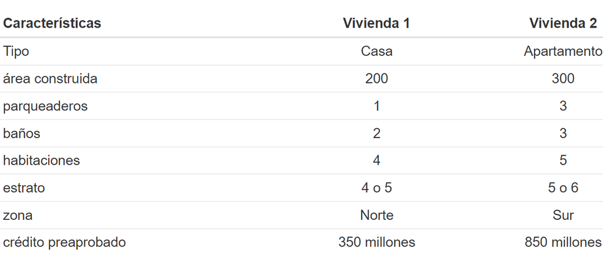

Condiciones

**Pasos requeridos para la obtención de los resultados**

1. Realice un filtro a la base de datos e incluya solo las ofertas de : base1: casas, de la zona norte de la ciudad. Presente los primeros 3 registros de las bases y algunas tablas que comprueben la consulta. (Adicional un mapa con los puntos de las bases. Discutir si todos los puntos se ubican en la zona correspondiente o se presentan valores en otras zonas, por que?).
2. Realice un análisis exploratorio de datos enfocado en la correlación entre la variable respuesta (precio de la casa) en función del área construida, estrato, numero de baños, numero de habitaciones y zona donde se ubica la vivienda. Use gráficos interactivos con el paquete plotly e interprete los resultados.
3. Estime un modelo de regresión lineal múltiple con las variables del punto anterior (precio = f(área construida, estrato, número de cuartos, número de parqueaderos, número de baños ) ) e interprete los coeficientes si son estadísticamente significativos. Las interpretaciones deber están contextualizadas y discutir si los resultados son lógicos. Adicionalmente interprete el coeficiente R2 y discuta el ajuste del modelo e implicaciones (que podrían hacer para mejorarlo).
4. Realice la validación de supuestos del modelo e interprete los resultados (no es necesario corregir en caso de presentar problemas, solo realizar sugerencias de que se podría hacer).
5. Con el modelo identificado debe predecir el precio de la vivienda con las características de la primera solicitud.
6. Con las predicciones del modelo sugiera potenciales ofertas que responda a la solicitud de la vivienda 1. Tenga encuentra que la empresa tiene crédito pre-aprobado de máximo 350 millones de pesos. Realice un análisis y presente en un mapa al menos 5 ofertas potenciales que debe discutir.
7. Realice los pasos del 1 al 6. Para la segunda solicitud que tiene un crédito pre-aprobado por valor de $850 millones.

## Exploración inicial de datos

Basándonos en la información proporcionada por el resumen y la estructura del conjunto de datos, podemos hacer varias observaciones significativas. El conjunto de datos consta de 8322 observaciones con 13 variables. Algunas de estas variables tienen valores faltantes, como piso, estrato, preciom, areaconst, parqueaderos, banios, habitaciones, longitud y latitud, lo que sugiere la necesidad de manejar estos valores faltantes antes de realizar análisis posteriores. Las variables zona, piso, tipo y barrio son de naturaleza categórica, mientras que las variables id, estrato, preciom, areaconst, parqueaderos, banios, habitaciones, longitud y latitud son numéricas. Además, la presencia de problemas detectados en los datos sugiere la posibilidad de inconsistencias o errores que deben abordarse durante el análisis. En resumen, este conjunto de datos proporciona una variedad de información sobre propiedades inmobiliarias, incluidos detalles sobre su ubicación, características y precios, pero requerirá un procesamiento cuidadoso para garantizar su validez y utilidad en el análisis posterior.

```
##        id           zona               piso              estrato
##  Min.   :   1   Length:8322        Length:8322        Min.   :3.000
##  1st Qu.:2080   Class :character   Class :character   1st Qu.:4.000
##  Median :4160   Mode  :character   Mode  :character   Median :5.000
##  Mean   :4160                                         Mean   :4.634
##  3rd Qu.:6240                                         3rd Qu.:5.000
##  Max.   :8319                                         Max.   :6.000
##  NA's   :3                                            NA's   :3
##     preciom         areaconst       parqueaderos        banios
##  Min.   :  58.0   Min.   :  30.0   Min.   : 1.000   Min.   : 0.000
##  1st Qu.: 220.0   1st Qu.:  80.0   1st Qu.: 1.000   1st Qu.: 2.000
##  Median : 330.0   Median : 123.0   Median : 2.000   Median : 3.000
##  Mean   : 433.9   Mean   : 174.9   Mean   : 1.835   Mean   : 3.111
##  3rd Qu.: 540.0   3rd Qu.: 229.0   3rd Qu.: 2.000   3rd Qu.: 4.000
##  Max.   :1999.0   Max.   :1745.0   Max.   :10.000   Max.   :10.000
##  NA's   :2        NA's   :3        NA's   :1605     NA's   :3
##   habitaciones        tipo              barrio             longitud
##  Min.   : 0.000   Length:8322        Length:8322        Min.   :-76.59
##  1st Qu.: 3.000   Class :character   Class :character   1st Qu.:-76.54
##  Median : 3.000   Mode  :character   Mode  :character   Median :-76.53
##  Mean   : 3.605                                         Mean   :-76.53
##  3rd Qu.: 4.000                                         3rd Qu.:-76.52
##  Max.   :10.000                                         Max.   :-76.46
##  NA's   :3                                              NA's   :3
##     latitud
##  Min.   :3.333
##  1st Qu.:3.381
##  Median :3.416
##  Mean   :3.418
##  3rd Qu.:3.452
##  Max.   :3.498
##  NA's   :3
```

[output not shown]

## 1. Realice un filtro a la base de datos

## Zona Norte

De acuerdo a la solicitud del informe se presenta a continuación un sub conjunto de datos que permite visualizar el contenido correspondiente al tipo de inmueble casa para la zona norte, en este sentido se destaca lo siguiente:

Las estadísticas descriptivas de las ofertas de casas en la zona norte revelan una amplia gama de características y variabilidad en los datos. Con un total de 722 registros, este conjunto de datos parece haber sido filtrado correctamente para incluir solo las ofertas de casas en la zona norte. Se observa la presencia de valores faltantes en algunos atributos, lo cual es consistente con la estructura original del dataset.

Además de los precios y el área construida, otros atributos como el número de parqueaderos, baños y habitaciones también varían significativamente, con valores máximos de 10 en cada caso. Estos atributos son cruciales para entender las características y comodidades de las casas en la zona norte.

```
## Primeros 3 registros de la base de datos filtrada:
```

| id | zona | piso | estrato | preciom | areaconst | parqueaderos | banios | habitaciones | tipo | barrio | longitud | latitud |
| --- | --- | --- | --- | --- | --- | --- | --- | --- | --- | --- | --- | --- |
| 1209 | Zona Norte | 02 | 5 | 320 | 150 | 2 | 4 | 6 | Casa | acopi | -76.51341 | 3.47968 |
| 1592 | Zona Norte | 02 | 5 | 780 | 380 | 2 | 3 | 3 | Casa | acopi | -76.51674 | 3.48721 |
| 4057 | Zona Norte | 02 | 6 | 750 | 445 | NA | 7 | 6 | Casa | acopi | -76.52950 | 3.38527 |

```
## Estadísticas descriptivas de las ofertas de casas en la zona norte:
```

|  | id | zona | piso | estrato | preciom | areaconst | parqueaderos | banios | habitaciones | tipo | barrio | longitud | latitud |
| --- | --- | --- | --- | --- | --- | --- | --- | --- | --- | --- | --- | --- | --- |
|  | Min. : 58.0 | Length:722 | Length:722 | Min. :3.000 | Min. : 89.0 | Min. : 30.0 | Min. : 1.000 | Min. : 0.000 | Min. : 0.000 | Length:722 | Length:722 | Min. :-76.59 | Min. :3.333 |
|  | 1st Qu.: 766.2 | Class :character | Class :character | 1st Qu.:3.000 | 1st Qu.: 261.2 | 1st Qu.: 140.0 | 1st Qu.: 1.000 | 1st Qu.: 2.000 | 1st Qu.: 3.000 | Class :character | Class :character | 1st Qu.:-76.53 | 1st Qu.:3.452 |
|  | Median :2257.0 | Mode :character | Mode :character | Median :4.000 | Median : 390.0 | Median : 240.0 | Median : 2.000 | Median : 3.000 | Median : 4.000 | Mode :character | Mode :character | Median :-76.52 | Median :3.468 |
|  | Mean :2574.6 | NA | NA | Mean :4.202 | Mean : 445.9 | Mean : 264.9 | Mean : 2.182 | Mean : 3.555 | Mean : 4.507 | NA | NA | Mean :-76.52 | Mean :3.460 |
|  | 3rd Qu.:4225.0 | NA | NA | 3rd Qu.:5.000 | 3rd Qu.: 550.0 | 3rd Qu.: 336.8 | 3rd Qu.: 3.000 | 3rd Qu.: 4.000 | 3rd Qu.: 5.000 | NA | NA | 3rd Qu.:-76.50 | 3rd Qu.:3.482 |
|  | Max. :8319.0 | NA | NA | Max. :6.000 | Max. :1940.0 | Max. :1440.0 | Max. :10.000 | Max. :10.000 | Max. :10.000 | NA | NA | Max. :-76.47 | Max. :3.496 |
|  | NA | NA | NA | NA | NA | NA | NA’s :287 | NA | NA | NA | NA | NA | NA |

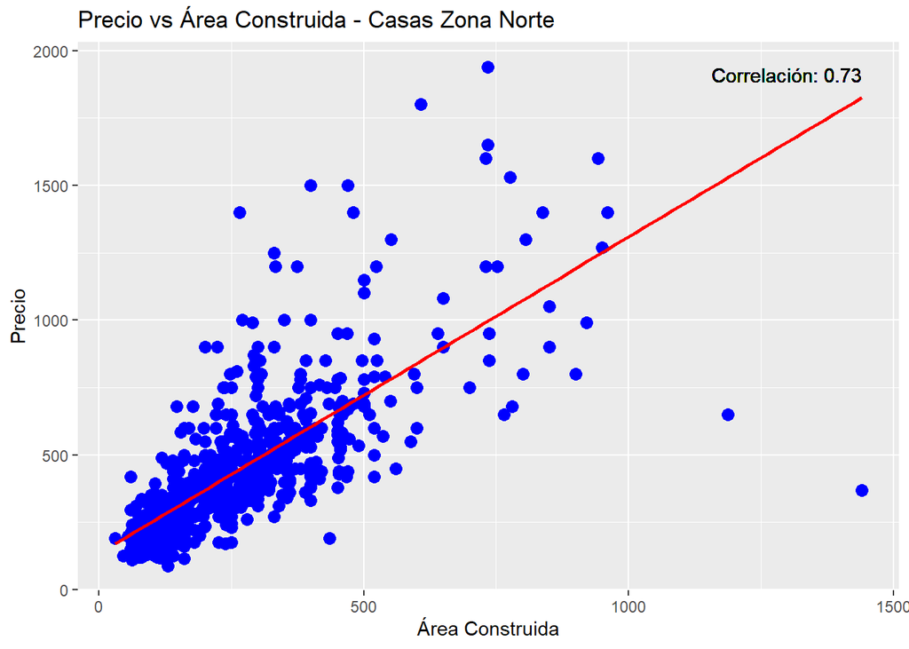

[interactive chart not shown]

```
## Tabla de frecuencia de tipos de vivienda en la zona norte:
```

| Var1 | Freq |
| --- | --- |
| Casa | 722 |

```
## Tabla de frecuencia de estratos en la zona norte:
```

| Var1 | Freq |
| --- | --- |
| 3 | 235 |
| 4 | 161 |
| 5 | 271 |
| 6 | 55 |

```
## Tabla de frecuencia de barrios en la zona norte (ordenada por frecuencia descendente):
```

| Var1 | Freq |
| --- | --- |
| acopi | 70 |
| brisas de los | 22 |
| alamos | 3 |
| barranquilla | 3 |
| base a√©rea | 2 |
| alameda del río | 1 |
| atanasio girardot | 1 |
| barrio tranquilo y | 1 |
| berlin | 1 |
| brisas del guabito | 1 |

## Zona Sur

Las estadísticas descriptivas de las ofertas de casas en la zona sur muestran una diversidad significativa en los datos. Con un total de 1939 registros, este conjunto de datos parece haber sido filtrado adecuadamente para incluir solo las ofertas de casas en la zona sur. Se observa la presencia de valores faltantes en algunos atributos, lo cual es consistente con la estructura original del dataset.

En relación a los precios de las casas, se evidencia una amplia variación, con valores que oscilan entre 77 y 1900 unidades monetarias. Tanto la mediana como la media sugieren que la mayoría de las casas tienen precios alrededor de 480 y 612.3 unidades monetarias, respectivamente.

El análisis del área construida también revela una diversidad similar, con valores que van desde 48 hasta 1600 metros cuadrados. La mediana y la media indican que la mayoría de las casas tienen un área construida de alrededor de 247 y 282.3 metros cuadrados, respectivamente.

Además de los precios y el área construida, otros atributos como el número de parqueaderos, baños y habitaciones también varían significativamente, con valores máximos de 10 en cada caso. Estos atributos son cruciales para comprender las características y comodidades de las casas en la zona sur.

```
## Primeros 3 registros de la base de datos filtrada:
```

| id | zona | piso | estrato | preciom | areaconst | parqueaderos | banios | habitaciones | tipo | barrio | longitud | latitud |
| --- | --- | --- | --- | --- | --- | --- | --- | --- | --- | --- | --- | --- |
| 5992 | Zona Sur | 02 | 4 | 400 | 280 | 3 | 5 | 3 | Casa | 3 de julio | -76.540 | 3.435 |
| 5157 | Zona Sur | 02 | 3 | 500 | 354 | 1 | 2 | 4 | Casa | alameda | -76.535 | 3.437 |
| 5501 | Zona Sur | 02 | 3 | 175 | 102 | NA | 2 | 4 | Casa | alameda | -76.537 | 3.435 |

```
## Estadísticas descriptivas de las ofertas de casas en la zona sur:
```

|  | id | zona | piso | estrato | preciom | areaconst | parqueaderos | banios | habitaciones | tipo | barrio | longitud | latitud |
| --- | --- | --- | --- | --- | --- | --- | --- | --- | --- | --- | --- | --- | --- |
|  | Min. : 1 | Length:1939 | Length:1939 | Min. :3.000 | Min. : 77.0 | Min. : 48.0 | Min. : 1.000 | Min. : 0.000 | Min. : 0.000 | Length:1939 | Length:1939 | Min. :-76.57 | Min. :3.333 |
|  | 1st Qu.:3230 | Class :character | Class :character | 1st Qu.:4.000 | 1st Qu.: 350.0 | 1st Qu.: 163.5 | 1st Qu.: 1.000 | 1st Qu.: 3.000 | 1st Qu.: 3.000 | Class :character | Class :character | 1st Qu.:-76.54 | 1st Qu.:3.368 |
|  | Median :4941 | Mode :character | Mode :character | Median :5.000 | Median : 480.0 | Median : 247.0 | Median : 2.000 | Median : 4.000 | Median : 4.000 | Mode :character | Mode :character | Median :-76.53 | Median :3.389 |
|  | Mean :4691 | NA | NA | Mean :4.842 | Mean : 612.3 | Mean : 282.3 | Mean : 2.415 | Mean : 4.173 | Mean : 4.514 | NA | NA | Mean :-76.53 | Mean :3.391 |
|  | 3rd Qu.:6264 | NA | NA | 3rd Qu.:6.000 | 3rd Qu.: 780.0 | 3rd Qu.: 350.0 | 3rd Qu.: 3.000 | 3rd Qu.: 5.000 | 3rd Qu.: 5.000 | NA | NA | 3rd Qu.:-76.53 | 3rd Qu.:3.413 |
|  | Max. :8305 | NA | NA | Max. :6.000 | Max. :1900.0 | Max. :1600.0 | Max. :10.000 | Max. :10.000 | Max. :10.000 | NA | NA | Max. :-76.46 | Max. :3.485 |
|  | NA | NA | NA | NA | NA | NA | NA’s :215 | NA | NA | NA | NA | NA | NA |

El gráfico de dispersión para la Zona Sur presenta un coeficiente de correlación de 0.67, lo que indica una fuerte correlación positiva entre el precio y el área construida. Esto significa que existe una relación directa entre ambas variables: a mayor área construida, mayor es el precio de la vivienda.

Sin embargo, la dispersión de los puntos alrededor de la línea de tendencia muestra una variación considerable en los precios.

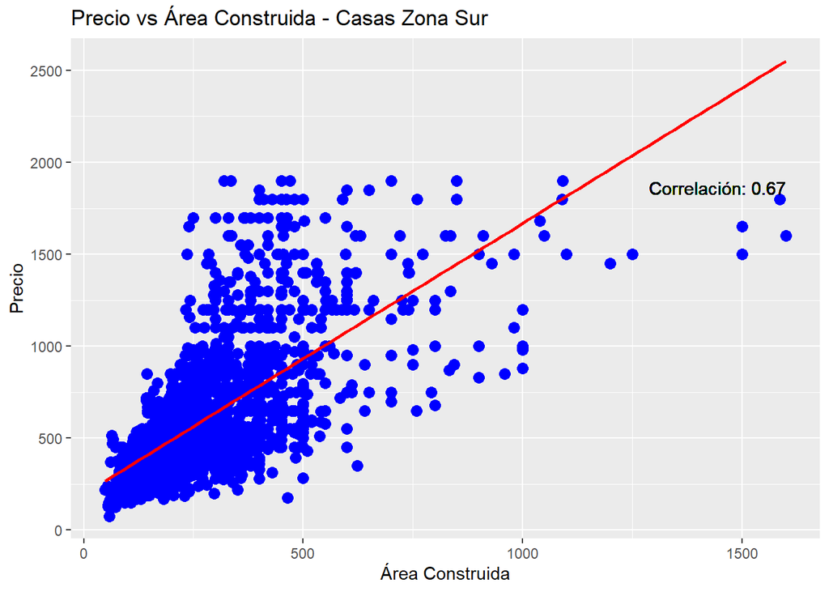

[interactive chart not shown]

```
## Tabla de frecuencia de tipos de vivienda en la zona sur:
```

| Var1 | Freq |
| --- | --- |
| Casa | 1939 |

```
## Tabla de frecuencia de estratos en la zona sur:
```

| Var1 | Freq |
| --- | --- |
| 3 | 181 |
| 4 | 525 |
| 5 | 652 |
| 6 | 581 |

```
## Tabla de frecuencia de barrios en la zona sur (ordenada por frecuencia descendente):
```

| Var1 | Freq |
| --- | --- |
| alameda | 3 |
| altos de guadalupe | 2 |
| bella suiza alta | 2 |
| 3 de julio | 1 |
| alborada | 1 |
| alf√©rez real | 1 |
| alferez real | 1 |
| aranjuez | 1 |
| barrio eucarístico | 1 |
| belalcazar | 1 |

## Zona Oriente

Las estadísticas descriptivas de las ofertas de casas en la zona oriente muestran una distribución similar en los datos. Con un total de 289 registros, se observa una variabilidad notable en los atributos considerados. Al igual que en otras zonas, se encuentran valores faltantes en algunos atributos, lo cual es coherente con la estructura original del dataset.

En cuanto a los precios de las casas, se observa una variación considerable, con valores que van desde 80 hasta 750 unidades monetarias. Tanto la mediana como la media sugieren que la mayoría de las casas tienen precios alrededor de 235 y 244.8 unidades monetarias, respectivamente.

El análisis del área construida también muestra una diversidad significativa, con valores que van desde 40 hasta 1745 metros cuadrados. La mediana y la media indican que la mayoría de las casas tienen un área construida de alrededor de 179 y 213.4 metros cuadrados, respectivamente.

```
## Primeros 3 registros de la base de datos filtrada:
```

| id | zona | piso | estrato | preciom | areaconst | parqueaderos | banios | habitaciones | tipo | barrio | longitud | latitud |
| --- | --- | --- | --- | --- | --- | --- | --- | --- | --- | --- | --- | --- |
| 1147 | Zona Oriente | NA | 3 | 250 | 70 | 1 | 3 | 6 | Casa | 20 de julio | -76.51168 | 3.43382 |
| 1169 | Zona Oriente | NA | 3 | 320 | 120 | 1 | 2 | 3 | Casa | 20 de julio | -76.51237 | 3.43369 |
| 1350 | Zona Oriente | NA | 3 | 350 | 220 | 2 | 2 | 4 | Casa | 20 de julio | -76.51537 | 3.43566 |

```
## Estadísticas descriptivas de las ofertas de casas en la zona Oriente:
```

|  | id | zona | piso | estrato | preciom | areaconst | parqueaderos | banios | habitaciones | tipo | barrio | longitud | latitud |
| --- | --- | --- | --- | --- | --- | --- | --- | --- | --- | --- | --- | --- | --- |
|  | Min. : 21 | Length:289 | Length:289 | Min. :3.000 | Min. : 80.0 | Min. : 40.0 | Min. :1.00 | Min. : 0.000 | Min. : 0.000 | Length:289 | Length:289 | Min. :-76.56 | Min. :3.389 |
|  | 1st Qu.: 424 | Class :character | Class :character | 1st Qu.:3.000 | 1st Qu.:160.0 | 1st Qu.: 122.0 | 1st Qu.:1.00 | 1st Qu.: 2.000 | 1st Qu.: 3.000 | Class :character | Class :character | 1st Qu.:-76.52 | 1st Qu.:3.423 |
|  | Median : 972 | Mode :character | Mode :character | Median :3.000 | Median :235.0 | Median : 179.0 | Median :1.00 | Median : 3.000 | Median : 5.000 | Mode :character | Mode :character | Median :-76.51 | Median :3.438 |
|  | Mean :1277 | NA | NA | Mean :3.028 | Mean :244.8 | Mean : 213.4 | Mean :1.39 | Mean : 2.965 | Mean : 5.318 | NA | NA | Mean :-76.51 | Mean :3.434 |
|  | 3rd Qu.:1345 | NA | NA | 3rd Qu.:3.000 | 3rd Qu.:310.0 | 3rd Qu.: 252.0 | 3rd Qu.:2.00 | 3rd Qu.: 4.000 | 3rd Qu.: 7.000 | NA | NA | 3rd Qu.:-76.50 | 3rd Qu.:3.449 |
|  | Max. :8271 | NA | NA | Max. :5.000 | Max. :750.0 | Max. :1745.0 | Max. :6.00 | Max. :10.000 | Max. :10.000 | NA | NA | Max. :-76.47 | Max. :3.490 |
|  | NA | NA | NA | NA | NA | NA | NA’s :148 | NA | NA | NA | NA | NA | NA |

Esta variabilidad puede ser explicada por una mayor influencia de otros factores como la ubicación, la calidad de la construcción, las características de la casa y las condiciones del mercado inmobiliario en la Zona Oriente.

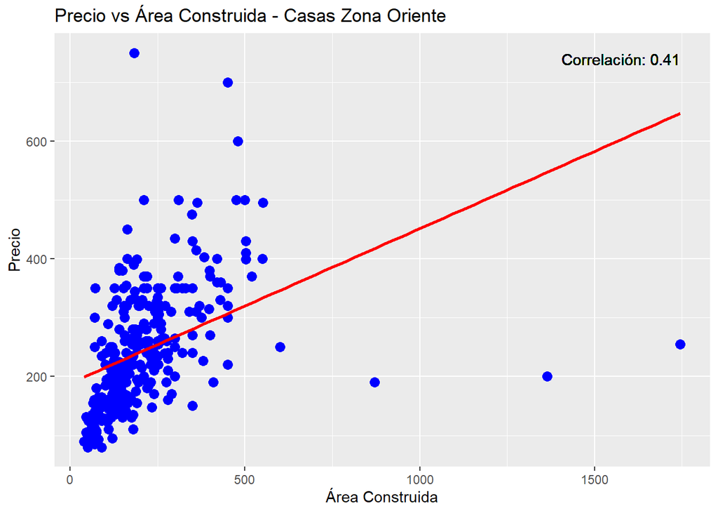

[interactive chart not shown]

```
## Tabla de frecuencia de tipos de vivienda en la zona oriente:
```

| Var1 | Freq |
| --- | --- |
| Casa | 289 |

```
## Tabla de frecuencia de estratos en la zona oriente:
```

| Var1 | Freq |
| --- | --- |
| 3 | 282 |
| 4 | 6 |
| 5 | 1 |

```
## Tabla de frecuencia de barrios en la zona oriente (ordenada por frecuencia descendente):
```

| Var1 | Freq |
| --- | --- |
| alfonso lópez | 19 |
| atanasio girardot | 7 |
| 20 de julio | 3 |
| antonio nariño | 2 |
| agua blanca | 1 |
| aguablanca | 1 |
| alfonso lopez | 1 |
| alfonso lópez i | 1 |
| arboleda campestre candelaria | 1 |
| autopista sur | 1 |

## Zona Oeste

Las estadísticas descriptivas de las ofertas de casas en la zona oeste reflejan una distribución diversa en los datos. Con un total de 169 registros, se aprecia una variabilidad considerable en los atributos considerados. Al igual que en otras zonas, se identifican valores faltantes en algunos atributos, lo cual es coherente con la estructura original del dataset.

En relación a los precios de las casas, se evidencia una variación amplia, con valores que oscilan entre 135 y 1999 unidades monetarias. Tanto la mediana como la media sugieren que la mayoría de las casas tienen precios alrededor de 680 y 736.4 unidades monetarias, respectivamente.

El análisis del área construida también muestra una diversidad notable, con valores que van desde 55 hasta 1200 metros cuadrados. La mediana y la media indican que la mayoría de las casas tienen un área construida de alrededor de 300 y 343.2 metros cuadrados, respectivamente.

```
## Primeros 3 registros de la base de datos filtrada:
```

| id | zona | piso | estrato | preciom | areaconst | parqueaderos | banios | habitaciones | tipo | barrio | longitud | latitud |
| --- | --- | --- | --- | --- | --- | --- | --- | --- | --- | --- | --- | --- |
| 6928 | Zona Oeste | 03 | 6 | 1850 | 302 | 4 | 4 | 3 | Casa | aguacatal | -76.54600 | 3.44400 |
| 7510 | Zona Oeste | 03 | 6 | 1950 | 400 | 4 | 5 | 3 | Casa | aguacatal | -76.55000 | 3.45600 |
| 7586 | Zona Oeste | 03 | 6 | 870 | 275 | 3 | 5 | 4 | Casa | aguacatal | -76.55074 | 3.45649 |

```
## Estadísticas descriptivas de las ofertas de casas en la zona Oeste:
```

|  | id | zona | piso | estrato | preciom | areaconst | parqueaderos | banios | habitaciones | tipo | barrio | longitud | latitud |
| --- | --- | --- | --- | --- | --- | --- | --- | --- | --- | --- | --- | --- | --- |
|  | Min. : 2 | Length:169 | Length:169 | Min. :3.000 | Min. : 135.0 | Min. : 55.0 | Min. :1.000 | Min. :0.00 | Min. : 0.000 | Length:169 | Length:169 | Min. :-76.57 | Min. :3.398 |
|  | 1st Qu.:5836 | Class :character | Class :character | 1st Qu.:4.000 | 1st Qu.: 430.0 | 1st Qu.: 233.0 | 1st Qu.:1.000 | 1st Qu.:3.00 | 1st Qu.: 4.000 | Class :character | Class :character | 1st Qu.:-76.55 | 1st Qu.:3.437 |
|  | Median :6725 | Mode :character | Mode :character | Median :5.000 | Median : 680.0 | Median : 300.0 | Median :2.000 | Median :4.00 | Median : 4.000 | Mode :character | Mode :character | Median :-76.54 | Median :3.444 |
|  | Mean :6235 | NA | NA | Mean :4.899 | Mean : 736.4 | Mean : 343.2 | Mean :2.311 | Mean :4.26 | Mean : 4.645 | NA | NA | Mean :-76.54 | Mean :3.443 |
|  | 3rd Qu.:7332 | NA | NA | 3rd Qu.:6.000 | 3rd Qu.: 930.0 | 3rd Qu.: 435.0 | 3rd Qu.:3.000 | 3rd Qu.:5.00 | 3rd Qu.: 5.000 | NA | NA | 3rd Qu.:-76.54 | 3rd Qu.:3.451 |
|  | Max. :8311 | NA | NA | Max. :6.000 | Max. :1999.0 | Max. :1200.0 | Max. :7.000 | Max. :9.00 | Max. :10.000 | NA | NA | Max. :-76.46 | Max. :3.494 |
|  | NA | NA | NA | NA | NA | NA | NA’s :37 | NA | NA | NA | NA | NA | NA |

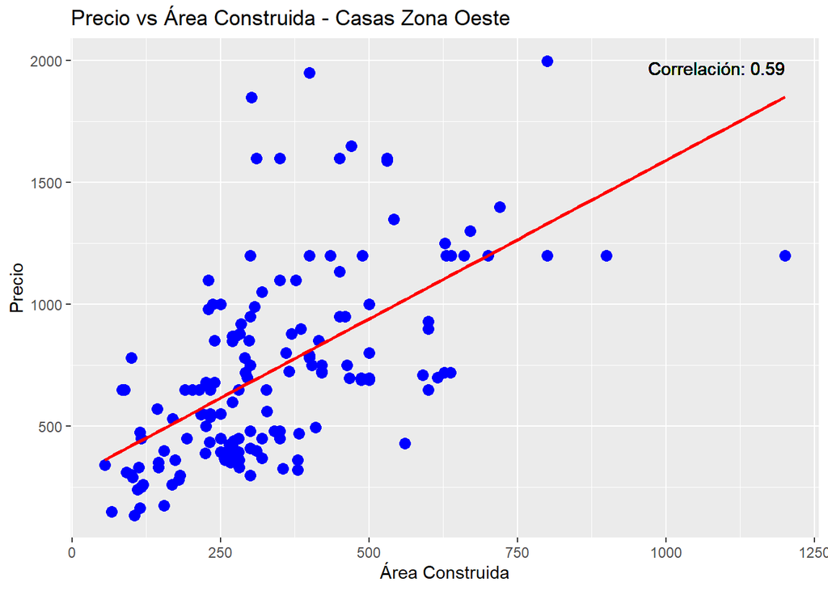

[interactive chart not shown]

```
## Tabla de frecuencia de tipos de vivienda en la zona Oeste:
```

| Var1 | Freq |
| --- | --- |
| Casa | 169 |

```
## Tabla de frecuencia de estratos en la zona Oeste:
```

| Var1 | Freq |
| --- | --- |
| 3 | 25 |
| 4 | 26 |
| 5 | 59 |
| 6 | 59 |

```
## Tabla de frecuencia de barrios en la zona oeste (ordenada por frecuencia descendente):
```

| Var1 | Freq |
| --- | --- |
| aguacatal | 11 |
| cristales | 10 |
| bella suiza | 7 |
| bellavista | 7 |
| el peñon | 4 |
| altos de guadalupe | 1 |
| bella suiza alta | 1 |
| el nacional | 1 |
| juanamb√∫ | 1 |
| la cascada | 1 |

## Zona Centro

Las estadísticas descriptivas de las ofertas de casas en la zona centro revelan una distribución diversificada en los datos. Con un total de 100 registros, se destaca una variabilidad significativa en los atributos considerados. Al igual que en otras zonas, se encuentran valores faltantes en algunos atributos, lo cual es coherente con la estructura original del dataset.

En cuanto a los precios de las casas, se observa una variación considerable, con valores que van desde 148 hasta 1100 unidades monetarias. Tanto la mediana como la media sugieren que la mayoría de las casas tienen precios alrededor de 310 y 339.2 unidades monetarias, respectivamente.

El análisis del área construida también muestra una diversidad significativa, con valores que van desde 74 hasta 750 metros cuadrados. La mediana y la media indican que la mayoría de las casas tienen un área construida de alrededor de 200 y 217.8 metros cuadrados, respectivamente.

```
## Primeros 3 registros de la base de datos filtrada:
```

| id | zona | piso | estrato | preciom | areaconst | parqueaderos | banios | habitaciones | tipo | barrio | longitud | latitud |
| --- | --- | --- | --- | --- | --- | --- | --- | --- | --- | --- | --- | --- |
| 5298 | Zona Centro | 01 | 3 | 650 | 240 | 2 | 4 | 4 | Casa | alameda | -76.53564 | 3.43521 |
| 5107 | Zona Centro | 02 | 4 | 400 | 460 | NA | 5 | 7 | Casa | alameda | -76.53471 | 3.43627 |
| 5117 | Zona Centro | 02 | 3 | 380 | 290 | NA | 4 | 8 | Casa | alameda | -76.53481 | 3.43712 |

```
## Estadísticas descriptivas de las ofertas de casas en la zona Centro:
```

|  | id | zona | piso | estrato | preciom | areaconst | parqueaderos | banios | habitaciones | tipo | barrio | longitud | latitud |
| --- | --- | --- | --- | --- | --- | --- | --- | --- | --- | --- | --- | --- | --- |
|  | Min. : 572 | Length:100 | Length:100 | Min. :3.00 | Min. : 148.0 | Min. : 74.0 | Min. :1.000 | Min. :0.00 | Min. : 0.00 | Length:100 | Length:100 | Min. :-76.54 | Min. :3.398 |
|  | 1st Qu.:2976 | Class :character | Class :character | 1st Qu.:3.00 | 1st Qu.: 238.8 | 1st Qu.:146.5 | 1st Qu.:1.000 | 1st Qu.:2.00 | 1st Qu.: 3.00 | Class :character | Class :character | 1st Qu.:-76.53 | 1st Qu.:3.436 |
|  | Median :3739 | Mode :character | Mode :character | Median :3.00 | Median : 310.0 | Median :200.0 | Median :1.000 | Median :3.00 | Median : 5.00 | Mode :character | Mode :character | Median :-76.53 | Median :3.439 |
|  | Mean :3816 | NA | NA | Mean :3.12 | Mean : 339.2 | Mean :217.8 | Mean :1.481 | Mean :3.01 | Mean : 5.11 | NA | NA | Mean :-76.53 | Mean :3.440 |
|  | 3rd Qu.:4765 | NA | NA | 3rd Qu.:3.00 | 3rd Qu.: 382.5 | 3rd Qu.:265.5 | 3rd Qu.:1.750 | 3rd Qu.:4.00 | 3rd Qu.: 7.00 | NA | NA | 3rd Qu.:-76.52 | 3rd Qu.:3.444 |
|  | Max. :6662 | NA | NA | Max. :6.00 | Max. :1100.0 | Max. :750.0 | Max. :6.000 | Max. :9.00 | Max. :10.00 | NA | NA | Max. :-76.50 | Max. :3.477 |
|  | NA | NA | NA | NA | NA | NA | NA’s :46 | NA | NA | NA | NA | NA | NA |

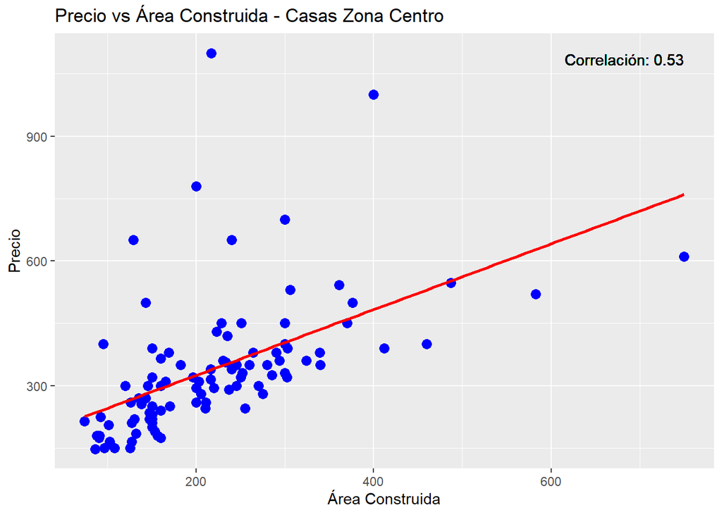

[interactive chart not shown]

```
## Tabla de frecuencia de tipos de vivienda en la zona Centro:
```

| Var1 | Freq |
| --- | --- |
| Casa | 100 |

```
## Tabla de frecuencia de estratos en la zona Centro:
```

| Var1 | Freq |
| --- | --- |
| 3 | 91 |
| 4 | 7 |
| 5 | 1 |
| 6 | 1 |

[output not shown]

| Var1 | Freq |
| --- | --- |
| aranjuez | 14 |
| bretaña | 11 |
| alameda | 9 |
| centro | 3 |
| belalcazar | 2 |
| benjamín herrera | 2 |
| barrio obrero | 1 |
| Belalcazar | 1 |
| colseguros | 1 |
| el troncal | 1 |